# Reproducible Research: Peer Assessment 1

```r
library(lubridate)
library(dplyr)
```

```r
library(ggplot2)
activity = read.csv('activity.csv')
```

## Calculate the total number of steps taken per day

```r
activity = na.omit(activity)
activity$date = as.Date(activity$date)

activity$day = format(activity$date , "%d")


activity %>% group_by(day) %>% summarize(sum(steps))
```

```
## # A tibble: 30 x 2
##    day   `sum(steps)`
##    <chr>        <int>
##  1 02           10726
##  2 03           21923
##  3 04           12116
##  4 05           23733
##  5 06           23754
##  6 07           23898
##  7 08            3219
##  8 09           12811
##  9 10            9900
## 10 11           22912
## # ... with 20 more rows
```

```r
activity %>% group_by(day) %>% summarize(mean(steps))
```

```
## # A tibble: 30 x 2
##    day   `mean(steps)`
##    <chr>         <dbl>
##  1 02             18.6
##  2 03             38.1
##  3 04             42.1
##  4 05             41.2
##  5 06             41.2
##  6 07             41.5
##  7 08             11.2
##  8 09             44.5
##  9 10             34.4
## 10 11             39.8
## # ... with 20 more rows
```

```r
activity %>% group_by(day) %>% summarize(median(steps))
```

```
## # A tibble: 30 x 2
##    day   `median(steps)`
##    <chr>           <dbl>
##  1 02                  0
##  2 03                  0
##  3 04                  0
##  4 05                  0
##  5 06                  0
##  6 07                  0
##  7 08                  0
##  8 09                  0
##  9 10                  0
## 10 11                  0
## # ... with 20 more rows
```

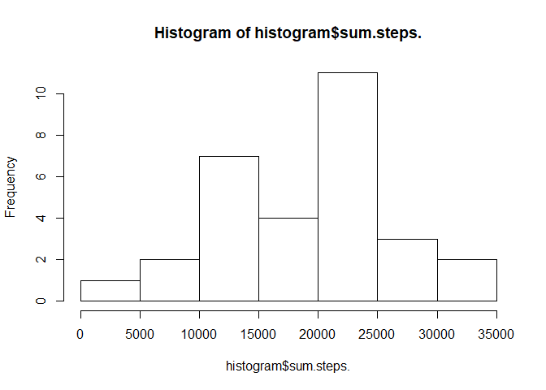

```r
histogram = data.frame(activity %>% group_by(day) %>% summarize(sum(steps)))

hist(histogram$sum.steps.)
```

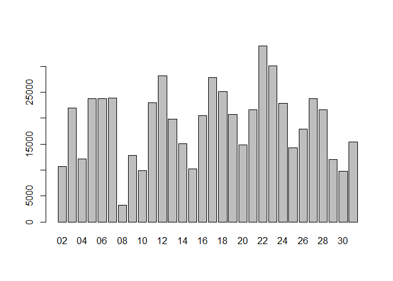

```r
barplot(height = histogram$sum.steps.,names.arg = histogram$day)
```

## Make a time series plot (i.e. type = “l”) of the 5-minute interval (x-axis) and the average number of steps taken, averaged across all days (y-axis)

## Which 5-minute interval, on average across all the days in the dataset, contains the maximum number of steps?

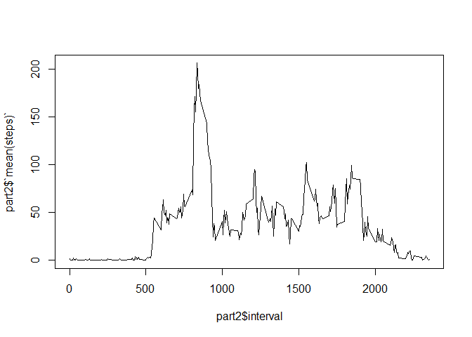

```r
part2 = activity %>% group_by(interval) %>% summarize(mean(steps))

plot(x = part2$interval,y = part2$`mean(steps)`,type = 'l')
```

```r
row = which((part2$`mean(steps)`)==max(part2$`mean(steps)`))

part2[row,]
```

```
## # A tibble: 1 x 2
##   interval `mean(steps)`
##      <int>         <dbl>
## 1      835          206.
```

## Calculate and report the total number of missing values in the dataset (i.e. the total number of rows with NA’s

```r
activity = read.csv('activity.csv')

na_count = function(a)
{
  sum(is.na(a))
}

sum(apply(activity,MARGIN = 1,na_count))
```

```
## [1] 2304
```

## Devise a strategy for filling in all of the missing values in the dataset. The strategy does not need to be sophisticated. For example, you could use the mean/median for that day, or the mean for that 5-minute interval, etc.

```r
for(i in 1:ncol(activity)){
  activity[is.na(activity[,i]), i] <- mean(activity[,i], na.rm = TRUE)
}
sum(apply(activity,MARGIN = 1,na_count))
```

```
## [1] 0
```

```r
activity$date = as.Date(activity$date)

activity$day = format(activity$date , "%d")


activity %>% group_by(day) %>% summarize(sum(steps))
```

```
## # A tibble: 31 x 2
##    day   `sum(steps)`
##    <chr>        <dbl>
##  1 01          21532.
##  2 02          10726
##  3 03          21923
##  4 04          22882.
##  5 05          23733
##  6 06          23754
##  7 07          23898
##  8 08          13985.
##  9 09          23577.
## 10 10          20666.
## # ... with 21 more rows
```

```r
activity %>% group_by(day) %>% summarize(mean(steps))
```

```
## # A tibble: 31 x 2
##    day   `mean(steps)`
##    <chr>         <dbl>
##  1 01             37.4
##  2 02             18.6
##  3 03             38.1
##  4 04             39.7
##  5 05             41.2
##  6 06             41.2
##  7 07             41.5
##  8 08             24.3
##  9 09             40.9
## 10 10             35.9
## # ... with 21 more rows
```

```r
activity %>% group_by(day) %>% summarize(median(steps))
```

```
## # A tibble: 31 x 2
##    day   `median(steps)`
##    <chr>           <dbl>
##  1 01               37.4
##  2 02                0
##  3 03                0
##  4 04               37.4
##  5 05                0
##  6 06                0
##  7 07                0
##  8 08               37.4
##  9 09               37.4
## 10 10               37.4
## # ... with 21 more rows
```

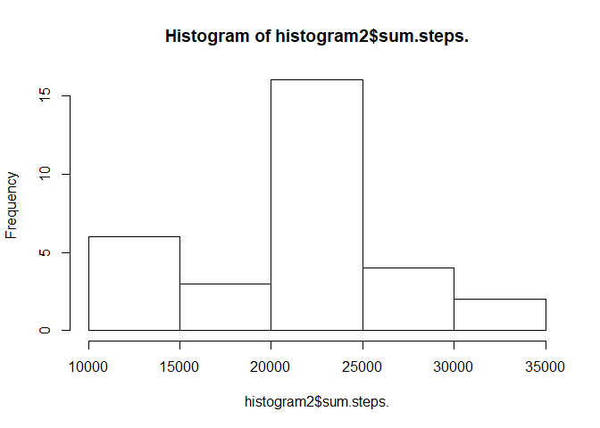

```r
histogram2 = data.frame(activity %>% group_by(day) %>% summarize(sum(steps)))

hist(histogram2$sum.steps.)
```

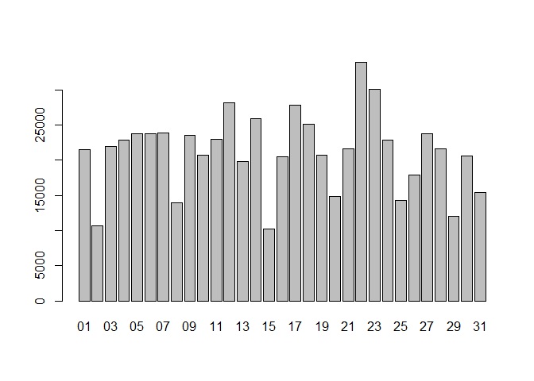

```r
barplot(height = histogram2$sum.steps.,names.arg = histogram2$day)
```

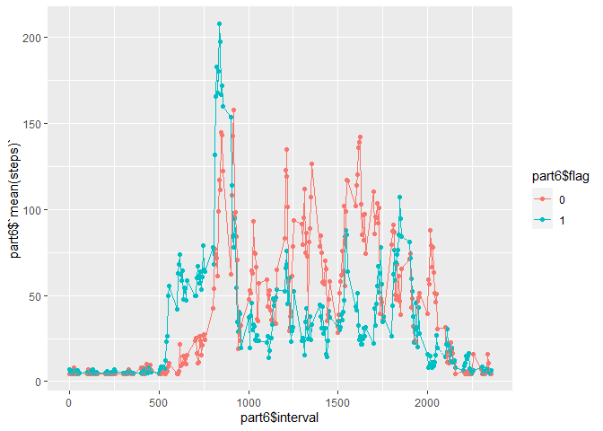

```r
activity$weekday = wday(activity$date, label=TRUE)

weekend_flag <- function(x)
{
  a = as.character(x)
  if(x=='Sat' | x=='Sun')
    return(0)
  else
    return(1)

}


activity$flag = as.factor(sapply(activity$weekday, weekend_flag))

part6 = activity %>% group_by(flag,interval) %>% summarize(mean(steps))

qplot(x = part6$interval,y = part6$`mean(steps)`,col = part6$flag) + geom_line()
```